# Q & K Box 10.2

Here we use the Medley and Clements (1998) data differently from the original analysis in Chapter 6. Now we are comparing diatom species diversity across streams. Streams are treated as a random factor, assuming these streams represent a random sample of all possible streams in this part of the Rocky Mountains. The design is unbalanced with between four and seven stations (level 1 units) on each stream (level 2 clusters). In addition to diatom diversity, zinc concentration was also recorded at each station (a level 1 covariate). We will do two analyses on these data. First, we will fit models that focus just on estimating the diatom diversity variance components for streams and for stations within streams, i.e. fit a null or random effects model. Second, we will include the covariate zinc concentration in our models and aim to estimate the variance associated with random intercepts and random slopes.

The data were used in the first edition, and the data file is here

### Preliminaries

First, load the required packages (afex, car, lattice, lme4, lmerTest, nlme, VCA)

Import the data file (medley_rand.csv)

```r
medley_rand <- read.csv("../data/medley_rand.csv")
head(medley_rand,10)
```

|  | stream | zinc | diversity | zn |
| --- | --- | --- | --- | --- |
| 1 | Eagle | BACK | 2.27 | 2 |
| 2 | Eagle | HIGH | 1.25 | 407 |
| 3 | Eagle | HIGH | 1.15 | 336 |
| 4 | Eagle | MED | 1.62 | 104 |
| 5 | Blue | BACK | 1.70 | 7 |
| 6 | Blue | HIGH | 0.63 | 1735 |
| 7 | Blue | BACK | 2.05 | 3 |
| 8 | Blue | BACK | 1.98 | 9 |
| 9 | Blue | HIGH | 1.04 | 691 |
| 10 | Blue | MED | 2.19 | 72 |

Set contrasts from afex

```
## setting contr.sum globally: options(contrasts=c('contr.sum', 'contr.poly'))
```

### Fit null/empty or random effects model without covariate

First fit OLS anova model with stream as random factor

```r
medley_rand.aov <- aov(diversity~stream, medley_rand)
```

Check residuals (no pattern, all OK)

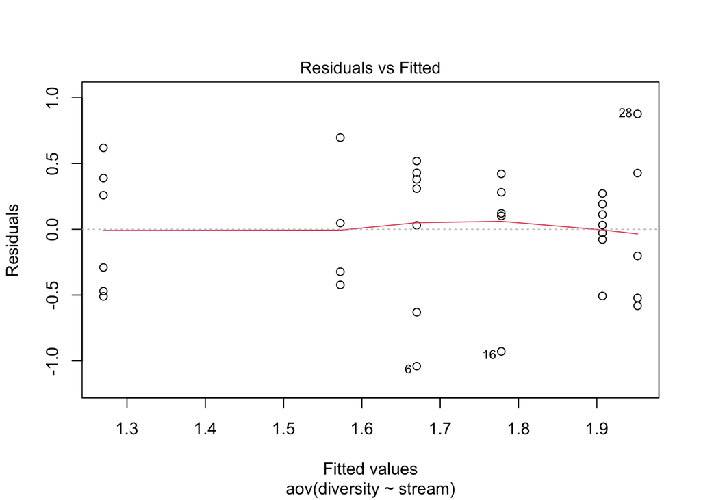

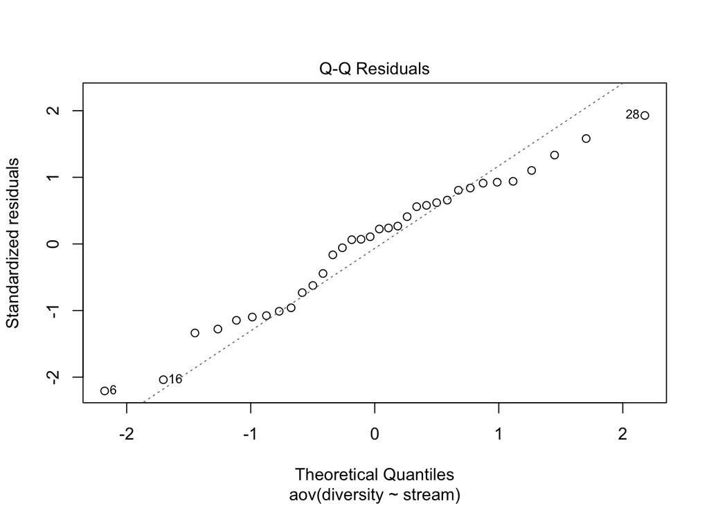

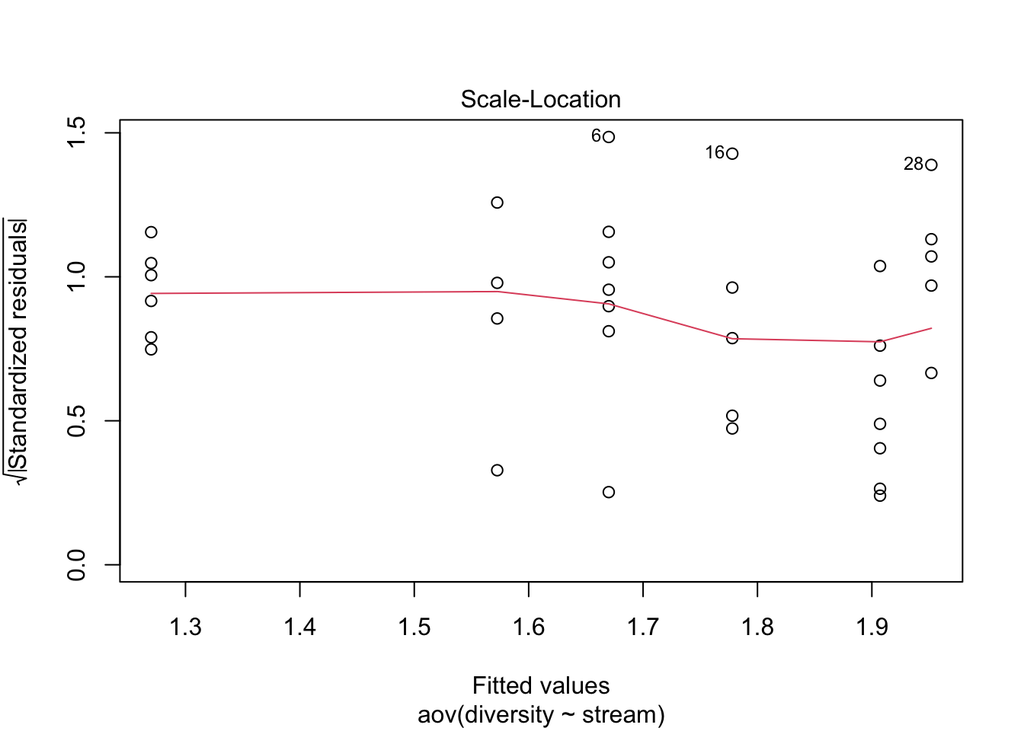

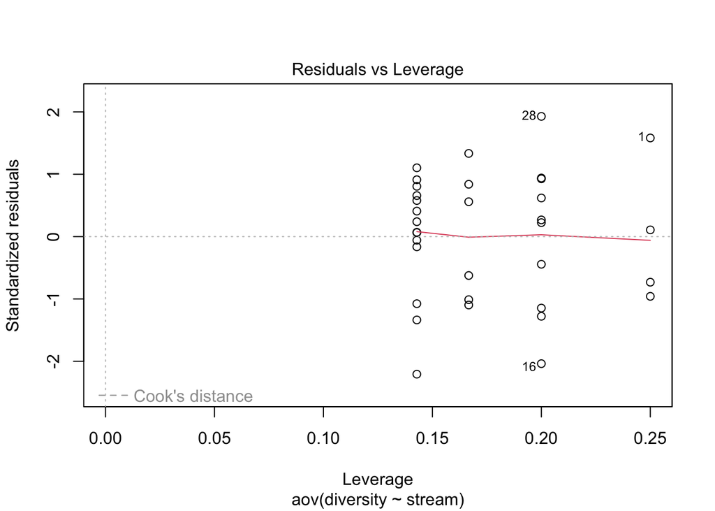

```r
plot(medley_rand.aov)
```

Get anova results

```r
summary(medley_rand.aov)
```

```
##             Df Sum Sq Mean Sq F value Pr(>F)
## stream       5  1.828  0.3656   1.411  0.251
## Residuals   28  7.255  0.2591
```

### Using VCA package to get anova variance component

Note: With OLS estimation, CIs can be negative)

```r
medley_rand.vca <- anovaMM(diversity~(stream), medley_rand)
```

```
## Convert variable stream from "character" to "factor"!
```

```r
medley_rand.vca
```

```
##
##
## Result Variance Component Analysis:
## -----------------------------------
##
##   Name   DF        SS       MS       VC       %Total   SD       CV[%]
## 1 total  31.348886                   0.278044 100      0.527299 31.125269
## 2 stream 5         1.827846 0.365569 0.01893  6.80842  0.137588 8.121501
## 3 error  28        7.255178 0.259113 0.259113 93.19158 0.509032 30.047023
##
## Mean: 1.694118 (N = 34)
##
## Experimental Design: unbalanced  |  Method: ANOVA
```

```r
VCAinference(medley_rand.vca, alpha=0.05, VarVC=TRUE, excludeNeg=FALSE, constrainCI=FALSE)
```

```
##
##
##
## Inference from (V)ariance (C)omponent (A)nalysis
## ------------------------------------------------
##
## > VCA Result:
## -------------
##
##   Name   DF      SS     MS     VC     %Total  SD     CV[%]   Var(VC)
## 1 total  31.3489               0.278  100     0.5273 31.1253 0.0049
## 2 stream 5       1.8278 0.3656 0.0189 6.8084  0.1376 8.1215  0.0018
## 3 error  28      7.2552 0.2591 0.2591 93.1916 0.509  30.047  0.0048
##
## Mean: 1.6941 (N = 34)
##
## Experimental Design: unbalanced  |  Method: ANOVA
##
##
## > VC:
## -----
##        Estimate  CI LCL CI UCL One-Sided LCL One-Sided UCL
## total    0.2780  0.1791 0.4897        0.1920        0.4457
## stream   0.0189 -0.0653 0.1032       -0.0518        0.0896
## error    0.2591  0.1632 0.4740        0.1755        0.4286
##
## > SD:
## -----
##        Estimate  CI LCL CI UCL One-Sided LCL One-Sided UCL
## total    0.5273  0.4232 0.6998        0.4381        0.6676
## stream   0.1376 -0.2555 0.3212       -0.2275        0.2994
## error    0.5090  0.4040 0.6884        0.4189        0.6547
##
## > CV[%]:
## --------
##        Estimate   CI LCL  CI UCL One-Sided LCL One-Sided UCL
## total   31.1253  24.9806 41.3053       25.8619       39.4077
## stream   8.1215 -15.0829 18.9581      -13.4281       17.6701
## error   30.0470  23.8447 40.6371       24.7292       38.6437
##
##
## 95% Confidence Level
## SAS PROC MIXED method used for computing CIs
```

### Fit mixed model using lme4

```r
medley_rand.reml <- lmer(diversity~(1|stream), medley_rand)
summary(medley_rand.reml)
```

```
## Linear mixed model fit by REML. t-tests use Satterthwaite's method [
## lmerModLmerTest]
## Formula: diversity ~ (1 | stream)
##    Data: medley_rand
##
## REML criterion at convergence: 54.3
##
## Scaled residuals:
##     Min      1Q  Median      3Q     Max
## -2.0787 -0.7689  0.2107  0.6707  2.0945
##
## Random effects:
##  Groups   Name        Variance Std.Dev.
##  stream   (Intercept) 0.02054  0.1433
##  Residual             0.25756  0.5075
## Number of obs: 34, groups:  stream, 6
##
## Fixed effects:
##             Estimate Std. Error     df t value Pr(>|t|)
## (Intercept)   1.6933     0.1053 5.1118   16.08 1.42e-05 ***
## ---
## Signif. codes:  0 '***' 0.001 '**' 0.01 '*' 0.05 '.' 0.1 ' ' 1
```

```r
medley_rand.ml <- lmer(diversity~(1|stream), medley_rand, REML=F)
summary(medley_rand.ml)
```

```
## Linear mixed model fit by maximum likelihood . t-tests use Satterthwaite's
##   method [lmerModLmerTest]
## Formula: diversity ~ (1 | stream)
##    Data: medley_rand
##
##      AIC      BIC   logLik deviance df.resid
##     57.5     62.1    -25.8     51.5       31
##
## Scaled residuals:
##     Min      1Q  Median      3Q     Max
## -2.0874 -0.7075  0.2287  0.7077  2.1584
##
## Random effects:
##  Groups   Name        Variance Std.Dev.
##  stream   (Intercept) 0.009928 0.09964
##  Residual             0.257183 0.50713
## Number of obs: 34, groups:  stream, 6
##
## Fixed effects:
##             Estimate Std. Error      df t value Pr(>|t|)
## (Intercept)  1.69361    0.09629 6.07706   17.59 1.92e-06 ***
## ---
## Signif. codes:  0 '***' 0.001 '**' 0.01 '*' 0.05 '.' 0.1 ' ' 1
```

CI on variance components

We need to square CIs from *lmer*, which are in SD units

```r
medley_rand.ci <- confint.merMod(medley_rand.reml)
```

```
## Computing profile confidence intervals ...
```

```r
medley_rand.vc <- (medley_rand.ci)^2
print(medley_rand.vc)
```

```
##                 2.5 %    97.5 %
## .sig01      0.0000000 0.1744225
## .sigma      0.1592729 0.4440721
## (Intercept) 2.1608963 3.6686745
```

### Now fit random intercept and/or slope models including covariate zinc.

First plot the regressions for each stream

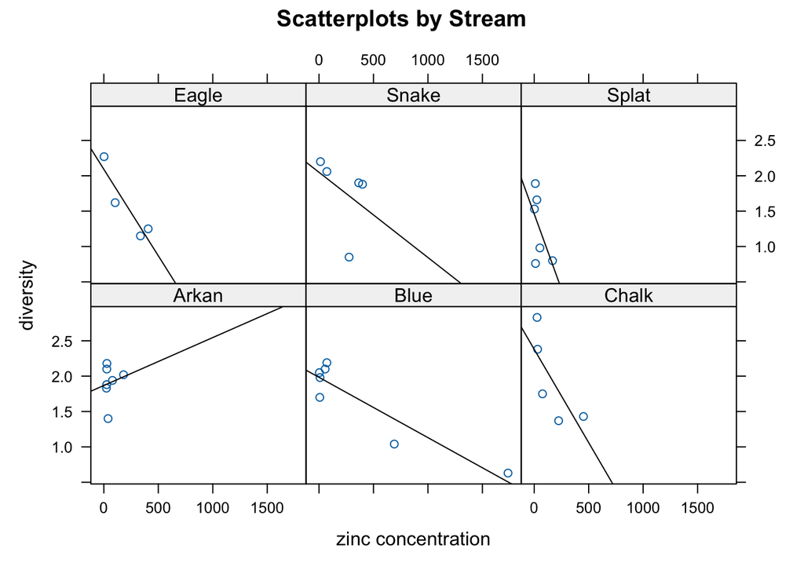

```r
panel.smoother <- function(x, y) {
  panel.xyplot(x, y)
  panel.lmline(x, y)
  }
xyplot(diversity~zn|stream,main="Scatterplots by Stream", ylab="diversity", xlab="zinc concentration", panel=panel.smoother, medley_rand)
```

**Note**: most slopes negative although sample size is very small

### Fit random slope and intercept model using lme4

```r
medley_randz.lmer1 <- lmer(diversity~zn +(zn|stream), REML=TRUE, medley_rand)
summary(medley_randz.lmer1)
```

```
## Linear mixed model fit by REML. t-tests use Satterthwaite's method [
## lmerModLmerTest]
## Formula: diversity ~ zn + (zn | stream)
##    Data: medley_rand
##
## REML criterion at convergence: 55.2
##
## Scaled residuals:
##     Min      1Q  Median      3Q     Max
## -2.1446 -0.7050  0.2234  0.6671  1.8617
##
## Random effects:
##  Groups   Name        Variance  Std.Dev.  Corr
##  stream   (Intercept) 9.796e-02 0.3129920
##           zn          3.551e-07 0.0005959 -0.72
##  Residual             1.455e-01 0.3815099
## Number of obs: 34, groups:  stream, 6
##
## Fixed effects:
##               Estimate Std. Error         df t value Pr(>|t|)
## (Intercept)  1.9026528  0.1541741  3.3321553  12.341 0.000676 ***
## zn          -0.0011524  0.0004287  1.2726781  -2.688 0.181485
## ---
## Signif. codes:  0 '***' 0.001 '**' 0.01 '*' 0.05 '.' 0.1 ' ' 1
##
## Correlation of Fixed Effects:
##    (Intr)
## zn -0.618
## optimizer (nloptwrap) convergence code: 0 (OK)
## Model failed to converge with max|grad| = 1.06439 (tol = 0.002, component 1)
## Model is nearly unidentifiable: very large eigenvalue
##  - Rescale variables?
```

No convergence presumably due to small and unequal sample sizes - try random intercept model

```r
medley_randz.lmer2 <- lmer(diversity~zn + (1|stream), REML=TRUE, medley_rand)
summary(medley_randz.lmer2, ddf="Kenward-Roger")
```

```
## Linear mixed model fit by REML. t-tests use Kenward-Roger's method [
## lmerModLmerTest]
## Formula: diversity ~ zn + (1 | stream)
##    Data: medley_rand
##
## REML criterion at convergence: 55.4
##
## Scaled residuals:
##     Min      1Q  Median      3Q     Max
## -2.1183 -0.6488  0.1606  0.6830  2.1086
##
## Random effects:
##  Groups   Name        Variance Std.Dev.
##  stream   (Intercept) 0.06032  0.2456
##  Residual             0.15512  0.3939
## Number of obs: 34, groups:  stream, 6
##
## Fixed effects:
##               Estimate Std. Error         df t value Pr(>|t|)
## (Intercept)  1.8631212  0.1282947  5.9077521  14.522  7.6e-06 ***
## zn          -0.0009613  0.0002292 29.3025865  -4.194 0.000232 ***
## ---
## Signif. codes:  0 '***' 0.001 '**' 0.01 '*' 0.05 '.' 0.1 ' ' 1
##
## Correlation of Fixed Effects:
##    (Intr)
## zn -0.312
```

```r
anova(medley_randz.lmer2, ddf="Kenward-Roger")
```

|  | Sum Sq | Mean Sq | NumDF | DenDF | F value | Pr(>F) |
| --- | --- | --- | --- | --- | --- | --- |
| zn | 2.728546 | 2.728546 | 1 | 29.30259 | 17.58935 | 0.0002318795 |

Get CIs on varcomps from medley_rand.lmer2

```r
medley_randz.ci <- confint.merMod(medley_randz.lmer2)
```

```
## Computing profile confidence intervals ...
```

```r
medley_randz.vc <- (medley_randz.ci)^2
print(medley_randz.vc)
```

```
##                    2.5 %       97.5 %
## .sig01      0.000000e+00 2.658587e-01
## .sigma      9.257588e-02 2.657698e-01
## (Intercept) 2.566196e+00 4.541983e+00
## zn          1.951020e-06 2.421419e-07
```

### Compare random intercept with random effects (null) model using ML (as zinc is fixed effect)

```r
medley_randz.lmer3 <- lmer(diversity~zn + (1|stream), REML=FALSE, medley_rand)
summary(medley_randz.lmer3)
```

```
## Linear mixed model fit by maximum likelihood . t-tests use Satterthwaite's
##   method [lmerModLmerTest]
## Formula: diversity ~ zn + (1 | stream)
##    Data: medley_rand
##
##      AIC      BIC   logLik deviance df.resid
##     45.9     52.0    -19.0     37.9       30
##
## Scaled residuals:
##     Min      1Q  Median      3Q     Max
## -2.1386 -0.6302  0.1412  0.7115  2.1838
##
## Random effects:
##  Groups   Name        Variance Std.Dev.
##  stream   (Intercept) 0.04592  0.2143
##  Residual             0.14982  0.3871
## Number of obs: 34, groups:  stream, 6
##
## Fixed effects:
##               Estimate Std. Error         df t value Pr(>|t|)
## (Intercept)  1.8615113  0.1170068  7.4478940  15.909 5.09e-07 ***
## zn          -0.0009519  0.0002196 30.8384764  -4.335 0.000144 ***
## ---
## Signif. codes:  0 '***' 0.001 '**' 0.01 '*' 0.05 '.' 0.1 ' ' 1
##
## Correlation of Fixed Effects:
##    (Intr)
## zn -0.333
```

```r
anova(medley_randz.lmer3, medley_rand.reml)
```

```
## refitting model(s) with ML (instead of REML)
```

|  | npar | AIC | BIC | logLik | deviance | Chisq | Df | Pr(>Chisq) |
| --- | --- | --- | --- | --- | --- | --- | --- | --- |
| medley_rand.reml | 3 | 57.50014 | 62.07922 | -25.75007 | 51.50014 | NA | NA | NA |
| medley_randz.lmer3 | 4 | 45.93814 | 52.04359 | -18.96907 | 37.93814 | 13.56199 | 1 | 0.0002308119 |

Try same model with nlme

```r
medley_rand_zinc.lme2 <- lme(fixed=diversity~zn, random=~1|stream/zn, method="REML", data=medley_rand)
summary(medley_rand_zinc.lme2)
```

```
## Linear mixed-effects model fit by REML
##   Data: medley_rand
##        AIC      BIC    logLik
##   65.40468 72.73336 -27.70234
##
## Random effects:
##  Formula: ~1 | stream
##         (Intercept)
## StdDev:    0.245595
##
##  Formula: ~1 | zn %in% stream
##         (Intercept)  Residual
## StdDev:   0.3655802 0.1465479
##
## Fixed effects:  diversity ~ zn
##                  Value  Std.Error DF   t-value p-value
## (Intercept)  1.8631211 0.12777831 27 14.580887   0e+00
## zn          -0.0009613 0.00022429 27 -4.285869   2e-04
##  Correlation:
##    (Intr)
## zn -0.312
##
## Standardized Within-Group Residuals:
##         Min          Q1         Med          Q3         Max
## -0.78816670 -0.24140519  0.05975661  0.25412012  0.78455703
##
## Number of Observations: 34
## Number of Groups:
##         stream zn %in% stream
##              6             34
```

Fit random intercept-only model using nlme (matches lme4 model above)

```r
medley_rand_zinc.lme1 <- lme(fixed=diversity~zn, random=~1|stream, method="REML", data=medley_rand)
summary(medley_rand_zinc.lme1)
```

```
## Linear mixed-effects model fit by REML
##   Data: medley_rand
##        AIC      BIC    logLik
##   63.40468 69.26762 -27.70234
##
## Random effects:
##  Formula: ~1 | stream
##         (Intercept)  Residual
## StdDev:   0.2455997 0.3938584
##
## Fixed effects:  diversity ~ zn
##                  Value  Std.Error DF   t-value p-value
## (Intercept)  1.8631214 0.12777972 27 14.580729   0e+00
## zn          -0.0009613 0.00022429 27 -4.285883   2e-04
##  Correlation:
##    (Intr)
## zn -0.312
##
## Standardized Within-Group Residuals:
##        Min         Q1        Med         Q3        Max
## -2.1182693 -0.6488025  0.1606048  0.6829671  2.1085586
##
## Number of Observations: 34
## Number of Groups: 6
```